# Exam 1

## Exam 1

#### Question

1. Laura lleva un registro detallado de los gastos relacionados con su carro. La tabla muestra los gastos semanales durante un mes completo, organizados por categorías.

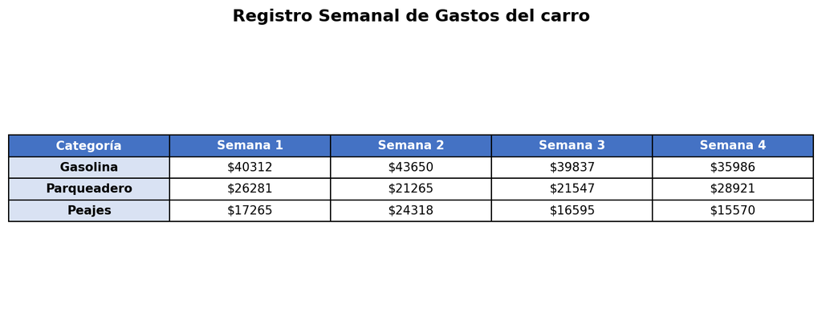

   A continuación se presentan cuatro tipos diferentes de gráficas que representan los mismos datos de la tabla:

   **Circular por categoría**

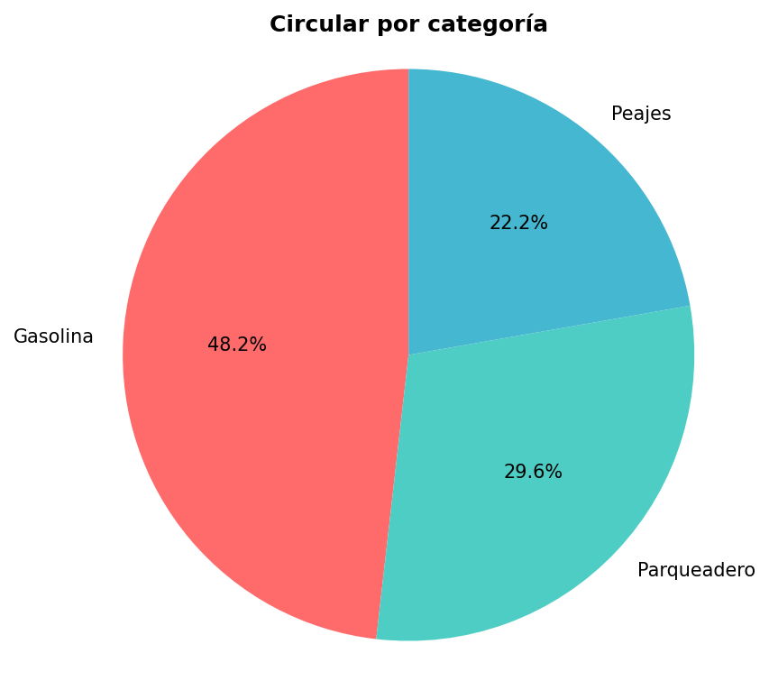

   **Barras apiladas por semana**

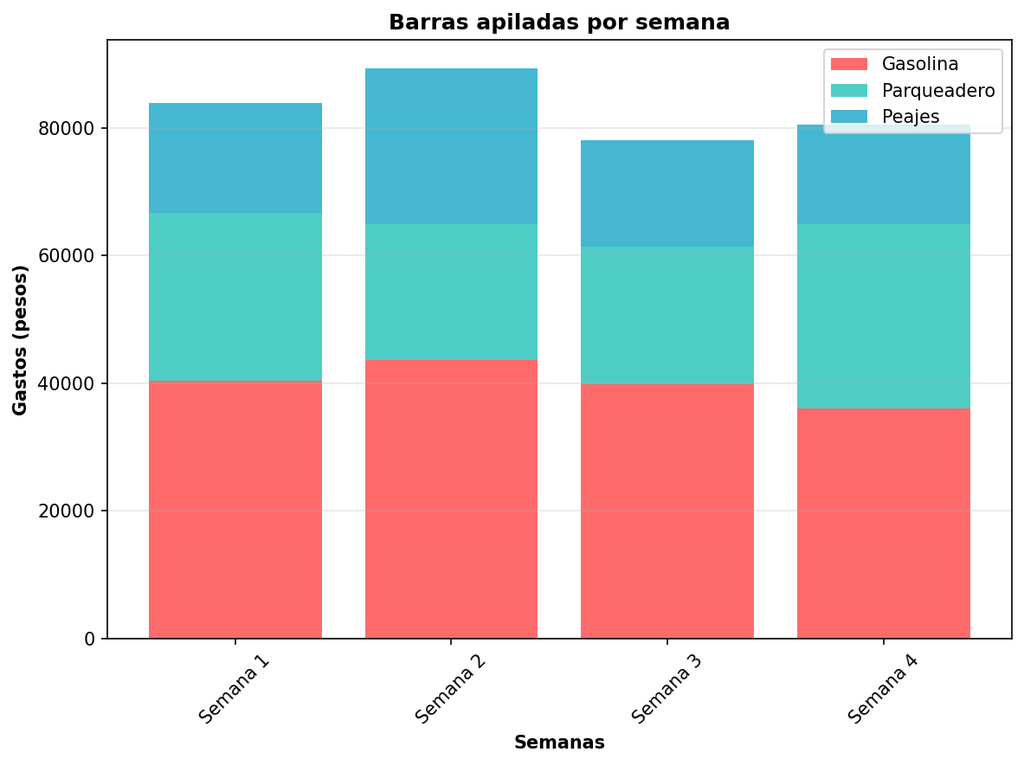

   **Circular por semana**

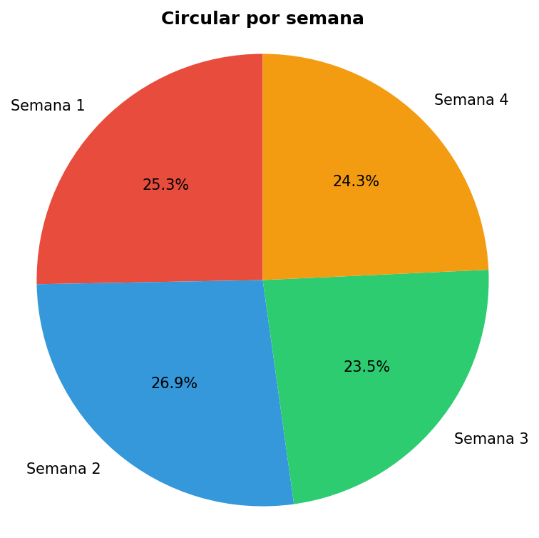

   **Barras agrupadas por categoría**

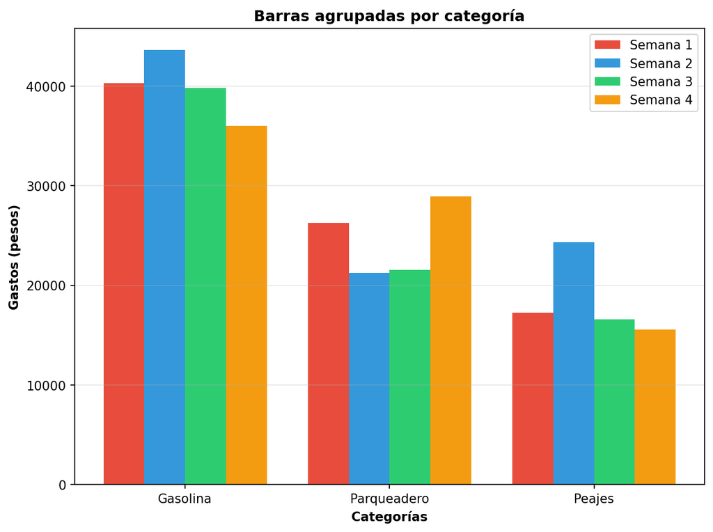

   Para analizar qué semana representó el mayor porcentaje del gasto total mensual, resuelva paso a paso:

   **IMPORTANTE - Formato de números:**
   - **Valores monetarios**: Sin separador de miles, use punto para decimales
     - Ejemplo: $16850.32 (no $16.850,32 ni $16850,32)
   - **Respuestas numéricas**: Sin separador de miles, use punto para decimales
     - Ejemplo: 1234.5678 (no 1.234,5678 ni 1234,5678)

### Paso 1: Identificación del mayor gasto semanal

   Observe la tabla y identifique cuál fue el mayor gasto semanal (total por semana).

   **Respuesta:** $

### Paso 2: Identificación del gasto total mensual

   Según la tabla, ¿cuál es el gasto total del mes (suma de todas las semanas)?

   **Respuesta:** $

### Paso 3: Configuración de la fórmula de porcentaje

   Para calcular el porcentaje, complete la fórmula con los valores identificados:

   Porcentaje = ( ÷ ) × 100%

### Paso 4: Verificación de valores

   Confirme que los valores del numerador y denominador son correctos: - Numerador (mayor gasto semanal): $ - Denominador (gasto total mensual): $

### Paso 5: Cálculo del porcentaje final

   Complete el cálculo del porcentaje:

   Porcentaje = ( ÷ ) × 100% = %

### Paso 6: Confirmación del tipo de gráfica (CON PUNTUACIÓN)

   Basándose en su análisis anterior, **seleccione qué tipo de gráfica permite identificar más fácilmente qué semana representó el mayor porcentaje del gasto total mensual**:

   Circular por semana / Barras agrupadas por categoría / Circular por categoría / Barras apiladas por semana

   **Conclusión:** La semana con mayor gasto representó el % del gasto total mensual.

#### Solution

   **NOTA IMPORTANTE - Configuración de evaluación automática:**
   - **Tolerancias configuradas**: Tolerancia 1 para respuestas numéricas monetarias, tolerancia 0.1 para porcentajes, tolerancia 0 para respuestas schoice
   - **Justificación**: Los valores monetarios son enteros grandes, tolerancia 1 evita rechazos incorrectos por diferencias mínimas de formato manteniendo precisión matemática
   - **Formato numérico**: Sin separador de miles, punto como separador decimal

### Análisis paso a paso del problema de gastos de vehículo

   Este problema de **interpretación de tablas** y **cálculo de porcentajes** requiere un análisis secuencial que demuestre el proceso de razonamiento matemático aplicado a contextos de gastos personales:

   **NOTA IMPORTANTE - Formato de números estandarizado:**
   - **Valores monetarios**: Sin separador de miles, use punto para decimales
     - Ejemplo: $16850.32 (no $16.850,32 ni $16850,32)
   - **Respuestas numéricas**: Sin separador de miles, punto como separador decimal
     - Ejemplo: 1234.5678 (no 1.234,5678 ni 1234,5678)
   - **Consistencia**: Mismo formato en enunciado, opciones y respuestas

### Paso 1: Identificación correcta del mayor gasto semanal ✓

   **Respuesta correcta:** $89233

   **Análisis de gastos semanales:**
   - Semana 1: $83858
   - Semana 2: $89233
   - Semana 3: $77979
   - Semana 4: $80477

   La semana 2 tuvo el mayor gasto con $89233.

### Paso 2: Identificación del gasto total mensual ✓

   **Respuesta correcta:** $331547

   El total mensual se calcula sumando todos los gastos semanales:

   $$\text{Total mensual} = 83858 + 89233 + 77979 + 80477 = 331547$$

### Paso 3: Configuración correcta de la fórmula ✓

   **Respuestas correctas:** Numerador = 89233, Denominador = 331547

   La fórmula de porcentaje requiere:
   - **Numerador:** El valor observado (89233 pesos)
   - **Denominador:** El valor total (331547 pesos)

### Paso 4: Verificación de valores ✓

   Los valores son coherentes con los datos de la tabla y representan correctamente:
   - El mayor gasto semanal individual
   - El gasto total mensual (suma de todas las semanas)

### Paso 5: Cálculo del porcentaje final ✓

   **Respuesta correcta:** 26.9%

   $$\text{Porcentaje} = \frac{89233}{331547} \times 100\% = 26.9\%$$

### Paso 6: Confirmación del tipo de gráfica ✓ (CON PUNTUACIÓN)

   **Opciones presentadas:**
   - **A**: Circular por semana ← **RESPUESTA CORRECTA**
   - **B**: Barras agrupadas por categoría
   - **C**: Circular por categoría
   - **D**: Barras apiladas por semana

   **Análisis de la respuesta correcta:**

   “Circular por semana”
   - Esta opción permite visualizar directamente qué semana representa el mayor porcentaje del total mensual
   - Muestra claramente las proporciones de cada semana respecto al total
   - Facilita la identificación inmediata de la semana con mayor participación porcentual
   - Es el tipo de gráfica más adecuado para comparar partes de un todo

   **Análisis de distractores:**
   - **Gráfica circular por categoría**: Muestra proporciones de categorías, no de semanas
   - **Gráfica de barras apiladas por semana**: Muestra composición pero no facilita comparación de totales
   - **Gráfica de barras agrupadas por categoría**: Agrupa por categoría, no por semana

### Verificación del proceso de razonamiento completo

   **Datos del problema:**
   - Mayor gasto semanal: $89233 (Semana 2)
   - Gasto total mensual: $331547
   - Porcentaje representado: 26.9%

   **El formato híbrido con puntuación dual (cloze + schoice) garantiza que los estudiantes:**

   **Parte Analítica (Pasos 1-5):**
   - **Lean cuidadosamente** la tabla para extraer datos precisos
   - **Identifiquen correctamente** el mayor valor semanal y el total mensual
   - **Configuren correctamente** la fórmula de porcentaje paso a paso
   - **Realicen cálculos** matemáticos sin saltar etapas del proceso

   **Parte de Confirmación (Paso 6):**
   - **Demuestren coherencia** entre su análisis numérico y la comprensión conceptual
   - **Identifiquen el tipo de gráfica** más apropiado para el análisis requerido
   - **Consoliden su aprendizaje** mediante validación de resultados

### Conclusión

   La semana 2 representó el **26.9%** del gasto total mensual de Laura en su carro.

   Esta respuesta es coherente porque:
   - Se basa en una lectura correcta de la tabla
   - Aplica correctamente la fórmula de porcentaje
   - El resultado está dentro del rango esperado (0% a 100%)
   - La gráfica seleccionada es la más apropiada para este tipo de análisis

   **Verificación adicional**: El total de gastos por categorías (Gasolina: $159785, Parqueadero: $98014, Peajes: $73748) suma exactamente $331547, confirmando la coherencia de los datos.